# Bike_Data_Project

Anishaa Balakrishnan

2024-01-29

## Case study: How does a bike-share navigate speedy success?

### **INTRODUCTION**

Welcome to the Cyclistic bike-share analysis case study! In this case study, you work for a fictional company, Cyclistic, along with some key team members.

### **Scenario**

You are a junior data analyst working on the marketing analyst team at Cyclistic, a bike-share company in Chicago. The director of marketing believes the company’s future success depends on maximizing the number of annual memberships. Therefore, your team wants to understand how casual riders and annual members use Cyclistic bikes differently. From these insights, your team will design a new marketing strategy to convert casual riders into annual members. But first, Cyclistic executives must approve your recommendations, so they must be backed up with compelling data insights and professional data visualizations.

### **ASK**

#### **Business Task:**

Understand how annual members and casual riders use cyclistic bikes differently.

#### **Key Stakeholders:**

The Director of Marketing and Manager Lily Moreno, Cyclistic marketing analytics team, Cyclistic executive team.

### **PREPARE**

#### 1. Data Source:

The historical bike trip dataset from Cyclistic is stored in a compressed file named ‘Divvy_Trips_2020_Q1,’ encompassing information for the initial three months of the year 2020.

#### 2. How the data is organized?

The dataset is structured in tabular format, featuring columns such as ride_id, rideable_type, started_at, ended_at, start_station_name, start_station_id, end_station_name, end_station_id, start_lat, start_lng, end_lat, end_lng, and member_casual. It comprises approximately 426,886 observations, spanning across 13 variables.

#### 3. Checking the credibility and data integrity

Upon loading the dataset into the RStudio Cloud source editor, I meticulously examined its contents. I methodically tackled missing values and scrutinized for any anomalies. Rigorous testing was implemented to ensure the correct assignment of data types to each variable. Remarkably extensive, the dataset is sizable. To maintain data privacy, personally identifiable information of riders has been deliberately omitted. As a testament to its credibility, the dataset satisfies the ROCCC conditions.

### **PROCESS**

Uploading the dataset to the Source editor of Posit cloud:

```r
bike_data <- read.csv("/cloud/project/bike_data/Divvy_Trips_2020_Q1.csv")
summary(bike_data)
```

```
##    ride_id          rideable_type       started_at          ended_at
##  Length:426887      Length:426887      Length:426887      Length:426887
##  Class :character   Class :character   Class :character   Class :character
##  Mode  :character   Mode  :character   Mode  :character   Mode  :character
##
##
##
##
##  start_station_name start_station_id end_station_name   end_station_id
##  Length:426887      Min.   :  2.0    Length:426887      Min.   :  2.0
##  Class :character   1st Qu.: 77.0    Class :character   1st Qu.: 77.0
##  Mode  :character   Median :176.0    Mode  :character   Median :175.0
##                     Mean   :209.8                       Mean   :209.3
##                     3rd Qu.:298.0                       3rd Qu.:297.0
##                     Max.   :675.0                       Max.   :675.0
##                                                         NA's   :1
##    start_lat       start_lng         end_lat         end_lng
##  Min.   :41.74   Min.   :-87.77   Min.   :41.74   Min.   :-87.77
##  1st Qu.:41.88   1st Qu.:-87.66   1st Qu.:41.88   1st Qu.:-87.66
##  Median :41.89   Median :-87.64   Median :41.89   Median :-87.64
##  Mean   :41.90   Mean   :-87.64   Mean   :41.90   Mean   :-87.64
##  3rd Qu.:41.92   3rd Qu.:-87.63   3rd Qu.:41.92   3rd Qu.:-87.63
##  Max.   :42.06   Max.   :-87.55   Max.   :42.06   Max.   :-87.55
##                                   NA's   :1       NA's   :1
##  member_casual
##  Length:426887
##  Class :character
##  Mode  :character
##
##
##
##
```

```r
str(bike_data)
```

```
## 'data.frame':    426887 obs. of  13 variables:
##  $ ride_id           : chr  "EACB19130B0CDA4A" "8FED874C809DC021" "789F3C21E472CA96" "C9A388DAC6ABF313" ...
##  $ rideable_type     : chr  "docked_bike" "docked_bike" "docked_bike" "docked_bike" ...
##  $ started_at        : chr  "2020-01-21 20:06:59" "2020-01-30 14:22:39" "2020-01-09 19:29:26" "2020-01-06 16:17:07" ...
##  $ ended_at          : chr  "2020-01-21 20:14:30" "2020-01-30 14:26:22" "2020-01-09 19:32:17" "2020-01-06 16:25:56" ...
##  $ start_station_name: chr  "Western Ave & Leland Ave" "Clark St & Montrose Ave" "Broadway & Belmont Ave" "Clark St & Randolph St" ...
##  $ start_station_id  : int  239 234 296 51 66 212 96 96 212 38 ...
##  $ end_station_name  : chr  "Clark St & Leland Ave" "Southport Ave & Irving Park Rd" "Wilton Ave & Belmont Ave" "Fairbanks Ct & Grand Ave" ...
##  $ end_station_id    : int  326 318 117 24 212 96 212 212 96 100 ...
##  $ start_lat         : num  42 42 41.9 41.9 41.9 ...
##  $ start_lng         : num  -87.7 -87.7 -87.6 -87.6 -87.6 ...
##  $ end_lat           : num  42 42 41.9 41.9 41.9 ...
##  $ end_lng           : num  -87.7 -87.7 -87.7 -87.6 -87.6 ...
##  $ member_casual     : chr  "member" "member" "member" "member" ...
```

Installing and loading packages:

```r
install.packages("dplyr")
library(dplyr)
install.packages("tidyverse")
library(tidyverse)
install.packages("janitor")
library(janitor)
```

Filtering the data frame by removing rows with missing values:

```r
bike_data <- bike_data %>%
  drop_na()
```

Deleting unwanted columns and renaming some columns for convenience

```r
bike_data_new <- subset(bike_data, select= -c(start_lat, start_lng, end_lat, end_lng))
bike_data_new <- bike_data_new %>%
  rename(start_time= started_at, end_time= ended_at, users= member_casual)
```

Converting the format of start_time and end_time columns to date-time format:

```r
bike_data_new <- bike_data_new %>%
  mutate(
    start_time = as.POSIXct(start_time, format = "%Y-%m-%d %H:%M:%S"),
    end_time = as.POSIXct(end_time, format = "%Y-%m-%d %H:%M:%S")
  )
```

Adding a new column called “ride_duration” to calculate the duration of each ride:

```r
bike_data_new <- bike_data_new %>%
  mutate(bike_data_new, ride_duration= end_time-start_time)
```

Removing the rows with negative values from “ride_duration” and converting the values to hours:minutes:seconds format:

```r
bike_data_new <- subset(bike_data_new,ride_duration>=0)
library(lubridate)
bike_data_new$ride_length <- seconds_to_period(bike_data_new$ride_duration) %>%
  as.duration() %>%
  hms::hms()
```

```r
bike_data_new <- bike_data_new %>%
  mutate(bike_data_new,day_of_week= wday(start_time, label=FALSE, week_start=1))
str(bike_data_new)
```

```
## 'data.frame':    426770 obs. of  12 variables:
##  $ ride_id           : chr  "EACB19130B0CDA4A" "8FED874C809DC021" "789F3C21E472CA96" "C9A388DAC6ABF313" ...
##  $ rideable_type     : chr  "docked_bike" "docked_bike" "docked_bike" "docked_bike" ...
##  $ start_time        : POSIXct, format: "2020-01-21 20:06:59" "2020-01-30 14:22:39" ...
##  $ end_time          : POSIXct, format: "2020-01-21 20:14:30" "2020-01-30 14:26:22" ...
##  $ start_station_name: chr  "Western Ave & Leland Ave" "Clark St & Montrose Ave" "Broadway & Belmont Ave" "Clark St & Randolph St" ...
##  $ start_station_id  : int  239 234 296 51 66 212 96 96 212 38 ...
##  $ end_station_name  : chr  "Clark St & Leland Ave" "Southport Ave & Irving Park Rd" "Wilton Ave & Belmont Ave" "Fairbanks Ct & Grand Ave" ...
##  $ end_station_id    : int  326 318 117 24 212 96 212 212 96 100 ...
##  $ users             : chr  "member" "member" "member" "member" ...
##  $ ride_duration     : 'difftime' num  451 223 171 529 ...
##   ..- attr(*, "units")= chr "secs"
##  $ ride_length       : 'hms' num  00:07:31 00:03:43 00:02:51 00:08:49 ...
##   ..- attr(*, "units")= chr "secs"
##  $ day_of_week       : num  2 4 4 1 4 5 5 5 5 5 ...
```

### **ANALYZE**

#### 1. Aggregate the data so it’s useful and accessible.

```r
summary(bike_data_new)
```

```
##    ride_id          rideable_type        start_time
##  Length:426770      Length:426770      Min.   :2020-01-01 00:04:44.00
##  Class :character   Class :character   1st Qu.:2020-01-24 13:55:44.50
##  Mode  :character   Mode  :character   Median :2020-02-17 00:14:44.50
##                                        Mean   :2020-02-14 01:10:37.75
##                                        3rd Qu.:2020-03-05 14:52:26.50
##                                        Max.   :2020-03-31 23:51:34.00
##     end_time                      start_station_name start_station_id
##  Min.   :2020-01-01 00:10:54.00   Length:426770      Min.   :  2.0
##  1st Qu.:2020-01-24 14:11:29.25   Class :character   1st Qu.: 77.0
##  Median :2020-02-17 01:45:07.50   Mode  :character   Median :176.0
##  Mean   :2020-02-14 01:32:45.02                      Mean   :209.7
##  3rd Qu.:2020-03-05 15:13:35.75                      3rd Qu.:298.0
##  Max.   :2020-05-19 20:10:34.00                      Max.   :675.0
##  end_station_name   end_station_id     users           ride_duration
##  Length:426770      Min.   :  2.0   Length:426770      Length:426770
##  Class :character   1st Qu.: 77.0   Class :character   Class :difftime
##  Mode  :character   Median :175.0   Mode  :character   Mode  :numeric
##                     Mean   :209.2
##                     3rd Qu.:296.0
##                     Max.   :675.0
##  ride_length        day_of_week
##  Length:426770     Min.   :1.000
##  Class1:hms        1st Qu.:2.000
##  Class2:difftime   Median :4.000
##  Mode  :numeric    Mean   :3.691
##                    3rd Qu.:5.000
##                    Max.   :7.000
```

#### 2. Perform calculations

We find the mean, median, maximum and minimum of ride_length for each user category( member and casual) and also for each day_of_week. The pivot tables help to quickly calculate and visualize data.

```r
result_summary <- bike_data_new %>%
  group_by(users)%>%
  summarize(mean_ride_length=mean(ride_length), median_ride_length=median(ride_length), max_ride_length=max(ride_length), min_ride_length=min(ride_length))
str(result_summary)
```

```
## tibble [2 × 5] (S3: tbl_df/tbl/data.frame)
##  $ users             : chr [1:2] "casual" "member"
##  $ mean_ride_length  : 'difftime' num [1:2] 5760.90529950582 760.626751090757
##   ..- attr(*, "units")= chr "secs"
##  $ median_ride_length: 'hms' num [1:2] 00:21:14 00:08:35
##   ..- attr(*, "units")= chr "secs"
##  $ max_ride_length   : 'difftime' num [1:2] 9387024 5627611
##   ..- attr(*, "units")= chr "secs"
##  $ min_ride_length   : 'difftime' num [1:2] 0 1
##   ..- attr(*, "units")= chr "secs"
```

```r
head(result_summary)
```

```
## # A tibble: 2 × 5
##   users  mean_ride_length median_ride_length max_ride_length min_ride_length
##   <chr>  <drtn>           <time>             <drtn>          <drtn>
## 1 casual 5760.9053 secs   21'14"             9387024 secs    0 secs
## 2 member  760.6268 secs   08'35"             5627611 secs    1 secs
```

```r
result_summary_1 <- bike_data_new %>%
  group_by(day_of_week)%>%
  summarize(mean_ride_length=mean(ride_length), median_ride_length=median(ride_length), max_ride_length=max(ride_length), min_ride_length=min(ride_length))
str(result_summary_1)
```

```
## tibble [7 × 5] (S3: tbl_df/tbl/data.frame)
##  $ day_of_week       : num [1:7] 1 2 3 4 5 6 7
##  $ mean_ride_length  : 'difftime' num [1:7] 1044.68919080859 1000.13685727246 1022.61176150676 1201.3851669213 ...
##   ..- attr(*, "units")= chr "secs"
##  $ median_ride_length: 'hms' num [1:7] 00:08:37 00:08:48 00:08:52 00:08:41 ...
##   ..- attr(*, "units")= chr "secs"
##  $ max_ride_length   : 'difftime' num [1:7] 5627611 4170291 4482201 9387024 ...
##   ..- attr(*, "units")= chr "secs"
##  $ min_ride_length   : 'difftime' num [1:7] 0 0 0 0 ...
##   ..- attr(*, "units")= chr "secs"
```

```r
head(result_summary_1)
```

```
## # A tibble: 6 × 5
##   day_of_week mean_ride_length median_ride_length max_ride_length
##         <dbl> <drtn>           <time>             <drtn>
## 1           1 1044.689 secs    08'37"             5627611 secs
## 2           2 1000.137 secs    08'48"             4170291 secs
## 3           3 1022.612 secs    08'52"             4482201 secs
## 4           4 1201.385 secs    08'41"             9387024 secs
## 5           5 1297.874 secs    08'34"             7039405 secs
## 6           6 1942.442 secs    10'16"             4753051 secs
## # ℹ 1 more variable: min_ride_length <drtn>
```

Determine the count of rides for each user category and for each day_of_week:

```r
rides_per_user <- bike_data_new %>%
  group_by(users)%>%
  summarize(number_of_rides=n())
head(rides_per_user)
```

```
## # A tibble: 2 × 2
##   users  number_of_rides
##   <chr>            <int>
## 1 casual           48363
## 2 member          378407
```

```r
rides_per_day <- bike_data_new %>%
  group_by(users,day_of_week)%>%
  summarize(number_of_rides=n())
head(rides_per_day)
```

```
## # A tibble: 6 × 3
## # Groups:   users [1]
##   users  day_of_week number_of_rides
##   <chr>        <dbl>           <int>
## 1 casual           1            4835
## 2 casual           2            5257
## 3 casual           3            5894
## 4 casual           4            4864
## 5 casual           5            5147
## 6 casual           6            7480
```

### **SHARE**

#### Plot 1

Relationship between average ride_length and users:

```r
library(ggplot2)
ggplot(result_summary, aes(x=users, y=mean_ride_length))+
  geom_bar(stat = "identity", fill="blue", color="black")+
  labs(title= "Mean ride length by users", x="users", y="Mean ride length")
```

```
## Defaulting to continuous.
```

[figure not shown]

#### Plot 2

Correlation between the average ride length and each day of the week:

```
## Defaulting to continuous.
```

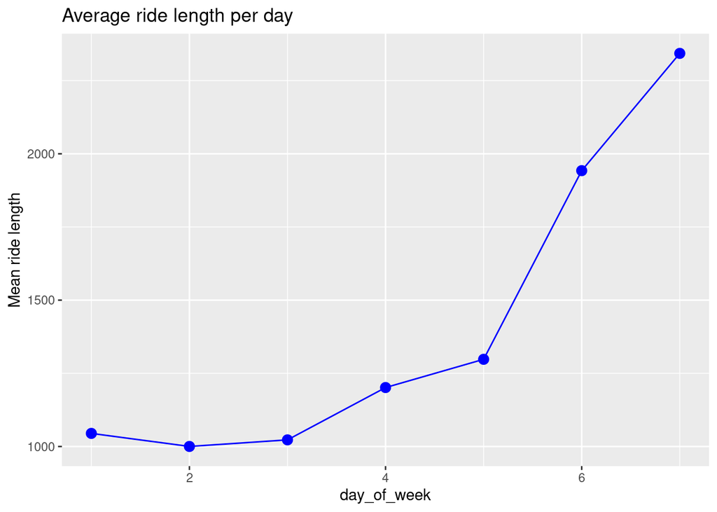

```r
ggplot(result_summary_1, aes(x=day_of_week, y=mean_ride_length))+
  geom_line(color="blue")+
  geom_point(color="blue", size=3)+
  labs(title="Average ride length per day",x="day_of_week", y="Mean ride length")
```

#### Plot 3

Relationship between number_of_rides and users:

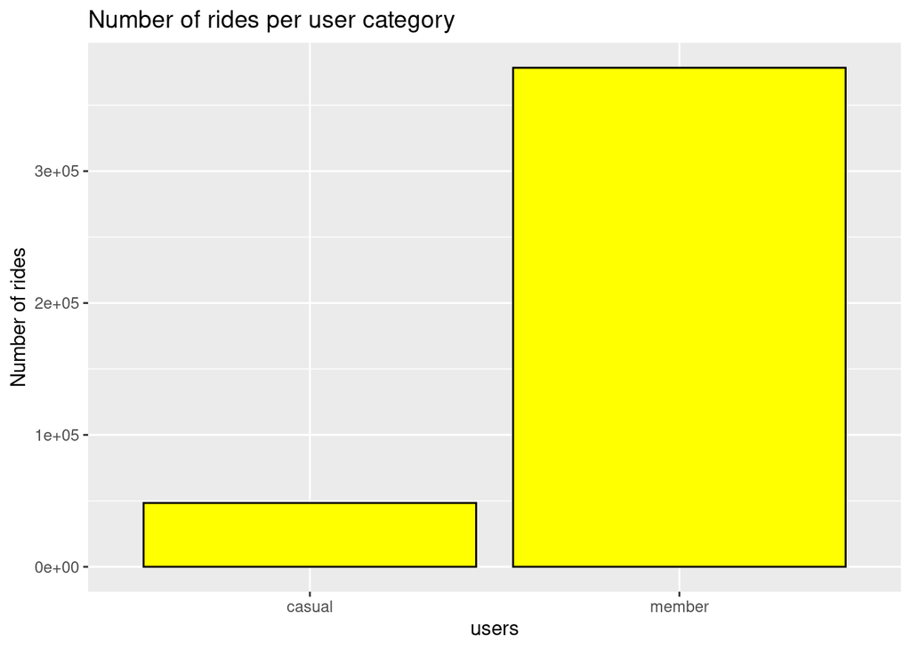

```r
ggplot(rides_per_user, aes(x=users, y=number_of_rides))+
  geom_bar(stat="identity", fill="yellow", color="black")+
  labs(title="Number of rides per user category", x="users", y="Number of rides")
```